# Run the cell below to generate the road map (do not modify it)

```python
%%javascript
var kernel = IPython.notebook.kernel;var thename = window.document.getElementById("notebook_name").innerHTML;var command = "THE_NOTEBOOK = " + "'"+thename+"'";kernel.execute(command);command="os.environ['THE_NOTEBOOK'] = THE_NOTEBOOK";kernel.execute(command);var cell = IPython.notebook.get_cell(2);cell.execute();IPython.notebook.get_cell(3).focus_cell();var x = $('.code_cell');$(x[1]).children('.input').hide();
```

```python
outputdir = "/tmp/tools/"
!mkdir -p $outputdir
!wget "https://www.dropbox.com/s/4g0pigmro4vo1b4/menutemplate?dl=0" -O /tmp/tools/menutemplate >> /tmp/toollog 2>&1
!wget "https://www.dropbox.com/s/3flttpzhsja8td7/construct_menu.py?dl=0" -O /tmp/tools/construct_menu.py >> /tmp/toollog 2>&1
!python /tmp/tools/construct_menu.py "{THE_NOTEBOOK}.ipynb" {outputdir}
from IPython.core.display import HTML
output_file_name = outputdir + THE_NOTEBOOK.replace(" ", "").replace("[", "").replace("]", "") + ".ipynb.html"
with open(output_file_name) as fp:
    html = fp.read()
HTML(html)
```

- ROADMAP

  - Anomaly Detection in Network Traffic with K-means clustering

    - Goals

    - Steps

  - 1. K-means

    - 1.1. Introduction

    - 1.2. How does it work ?

    - 1.3. Illustrative example

      - Question 1

        - Question 1.1

        - Question 1.2

        - Question 1.3

        - Question 1.4

        - Question 1.5

        - Question 1.6

        - Question 1.7

  - 2. Usecase: Network Intrusion

    - 2.1. Data

    - 2.2. Clustering without using categorical features

      - 2.2.1. Loading data

        - Question 2

        - Question 3

      - 2.2.3. Evaluating model

        - Question 4

        - Question 5

      - 2.2.4. Choosing K

        - Question 6

      - 2.2.5 Normalizing features

        - Question 7

        - Question 8

        - Question 9

    - 2.3. Clustering using categorical features

      - 2.3.1 Loading data

        - Question 10

      - 2.3.2. Building models

        - Question 11

    - 2.4. Anomaly detection

      - Question 12

      - Question 13

      - Question 14

- QUESTIONS

  - Question 1

    - Question 1.1

    - Question 1.2

    - Question 1.3

    - Question 1.4

    - Question 1.5

    - Question 1.6

    - Question 1.7

  - Question 2

  - Question 3

  - Question 4

  - Question 5

  - Question 6

  - Question 7

  - Question 8

  - Question 9

  - Question 10

  - Question 11

  - Question 12

  - Question 13

  - Question 14

# Anomaly Detection in Network Traffic with K-means clustering

We can categorize machine learning algorithms into two main groups: **supervised learning** and **unsupervised learning**. With supervised learning algorithms, in order to predict unknown values for new data, we have to know the target value for many previously-seen examples. In contrast, unsupervised learning algorithms explore the data which has no target attribute to find some intrinsic structures in them.

Clustering is a technique for finding similar groups in data, called **clusters**. Clustering is often called an unsupervised learning task as no class values denoting an a priori grouping of the data instances are given.

In this notebook, we will use K-means, a very well known clustering algorithm to detect anomaly network connections based on statistics about each of them. For a thorough overview of K-means clustering, from a research perspective, have a look at this wonderful [tutorial](http://theory.stanford.edu/~sergei/slides/kdd10-thclust.pdf).

## Goals

We expect students to:

- Learn (or revise) and understand the K-means algorithm
- Implement a simple K-means algorithm
- Use K-means to detect anomalies network connection data

## Steps

1. In section 1, we will have an overview about K-means then implement a simple version of it.
2. In section 2, we build models with and without categorical features.
3. Finally, in the last section, using our models, we will detect unsual connections.

# 1. K-means

## 1.1. Introduction

Clustering is a typical and well-known type of unsupervised learning. Clustering algorithms try to find natural groupings in data. Similar data points (according to some notion of similarity) are considered in the same group. We call these groups **clusters**.

K-Means clustering is a simple and widely-used clustering algorithm. Given value of $k$, it tries to build $k$ clusters from samples in the dataset. Therefore, $k$ is an hyperparameter of the model. The right value of $k$ is not easy to determine, as it highly depends on the data set and the way that data is featurized.

To measue the similarity between any two data points, K-means requires the definition of a distance funtion between data points. What is a distance? It is a value that indicates how close two data points are in their space. In particular, when data points lie in a $d$-dimensional space, the Euclidean distance is a good choice of a distance function, and is supported by MLLIB.

In K-means, a cluster is a group of points, with a representative entity called a centroid. A centroid is also a point in the data space: the center of all the points that make up the cluster. It's defined to be the arithmetic mean of the points. In general, when working with K-means, each data sample is represented in a $d$-dimensional numeric vector, for which it is easier to define an appropriate distance function. As a consequence, in some applications, the original data must be transformed into a different representation, to fit the requirements of K-means.

## 1.2. How does it work ?

Given $k$, the K-means algorithm works as follows:

1. Randomly choose $k$ data points (seeds) to be the initial centroids
2. Assign each data point to the **closest centroid**
3. Re-compute (update) the centroids using the current cluster memberships
4. If a convergence criterion is not met, go to step 2

We can also terminate the algorithm when it reaches an iteration budget, which yields an approximate result. From the pseudo-code of the algorithm, we can see that K-means clustering results can be sensitive to the order in which data samples in the data set are explored. A sensible practice would be to run the analysis several times, randomizing objects order; then, average the cluster centres of those runs and input the centres as initial ones for one final run of the analysis.

## 1.3. Illustrative example

One of the best ways to study an algorithm is trying implement it. In this section, we will go step by step to implement a simple K-means algorithm.

[figure not shown]

### Question 1

#### Question 1.1

Complete the below function to calculate an euclidean distance between any two points in $d$-dimensional data space

```python
import numpy as np

# calculate distance between two d-dimensional points
def euclidean_distance(p1, p2):
    return np.sqrt(np.sum((np.array(p1) - np.array(p2))**2))

# test our function
assert (round(euclidean_distance([1,2,3] , [10,18,12]), 2) == 20.45), "Function's wrong"
```

#### Question 1.2

Given a data point and the current set of centroids, complete the function below to find the index of the closest centroid for that data point.

```python
def find_closest_centroid(datapoint, centroids):
    # find the index of the closest centroid of the given data point.
    result =  0
    for i in range(len(centroids)):
        if euclidean_distance(datapoint,centroids[i]) < euclidean_distance(datapoint,centroids[result]):
            result = i
    return result

assert(find_closest_centroid( [1,1,1], [ [2,1,2], [1,2,1], [3,1,2] ] ) == 1), "Function's wrong"
```

#### Question 1.3

Write a function to randomize $k$ initial centroids.

```python
np.random.seed(22324)

# randomize initial centroids
def randomize_centroids(data, k):
    centroids = []
    indexes = np.random.randint(0, len(data), size=k)
    for i in indexes:
        centroids.append(data[i])
    return centroids

assert(len(
    randomize_centroids(
        np.array([
            np.array([2,1,2]),
            np.array([1,2,1]),
            np.array([3,1,2])
             ]),
        2)) == 2), "Wrong function"
```

#### Question 1.4

Write function `check_converge` to check the stop creteria of the algorithm.

```python
MAX_ITERATIONS = 10

# return True if clusters have converged , otherwise, return False
def check_converge(centroids, old_centroids, num_iterations, threshold=0):
    # if it reaches an iteration budget
    if num_iterations >= MAX_ITERATIONS:
        # check if the centroids don't move (or very slightly)
        print(euclidean_distance(centroids, old_centroids))
        if euclidean_distance(centroids, old_centroids) <= threshold :
            return True
        else:
            return False
    return
```

COMMENTS: we have to decide what is maximum number of iterations needed before check if clusters have converge or not.

#### Question 1.5

Write function `update_centroid` to update the new positions for the current centroids based on the position of their members.

```python
# centroids: a list of centers
# cluster: a list of k elements. Each element i-th is a list of data points that are assigned to center i-th
def update_centroids(centroids, cluster):
    for i in range(len(centroids)):
        centroids[i] = np.mean(cluster[i], axis=0)
    return centroids
```

```python
# result = np.mean(X_iris, axis=0)
# print(result)
```

#### Question 1.6

Complete the K-means algorithm scheleton below, with the functions you wrote above.

```python
# data : set of data points
# k : number of clusters
# centroids: initial list of centroids
def kmeans(data, k, centroids=None):

    # randomize the centroids if they are not given
    if not centroids:
        centroids = randomize_centroids(data, k)

    old_centroids = centroids[:]

    iterations = 0
    while True:
        iterations += 1

        # init empty clusters
        clusters = [[] for i in range(k)]

        # assign each data point to the closest centroid
        for datapoint in data:
            # find the closest center of each data point
            centroid_idx = find_closest_centroid(datapoint, centroids)

            # assign datapoint to the closest cluster
            clusters[centroid_idx].append(datapoint)

        # keep the current position of centroids before changing them
        old_centroids = centroids[:]

        # update centroids
        centroids = update_centroids(old_centroids, clusters)

        # if the stop criteria are met, stop the algorithm
        if check_converge(centroids, old_centroids, iterations, threshold=0) == True:
            break
    print('clusters :'+str(len(clusters)))
    return centroids
```

Next, we will test our algorithm on [Fisher's Iris dataset](http://en.wikipedia.org/wiki/Iris_flower_data_set), and plot the resulting clusters in 3D.

#### Question 1.7

The code below can be used to test your algorithm with three different datasets: Iris, Moon and Blob. Run your algorithm to cluster datapoints in these datasets, plot the results and discuss about them. Do you think that our algorithm works well? Why?

```
0.0
clusters :3
```

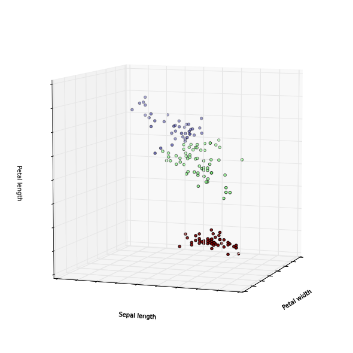

```python
# the sourcecode in this cell is inspired from
# https://gist.github.com/bbarrilleaux/9841297

%matplotlib inline

from sklearn import datasets, cluster
import numpy as np
import matplotlib.pyplot as plt
from mpl_toolkits.mplot3d import Axes3D

# load data
iris = datasets.load_iris()
X_iris = iris.data
y_iris = iris.target

# do the clustering
centers = kmeans(X_iris, k=3)
labels = [find_closest_centroid(datapoint, centers) for datapoint in X_iris]

# print(centers)

#plot the clusters in color
fig = plt.figure(1, figsize=(8, 8))
plt.clf()
ax = Axes3D(fig, rect=[0, 0, 1, 1], elev=8, azim=200)
plt.cla()
ax.scatter(X_iris[:, 3], X_iris[:, 0], X_iris[:, 2], c=labels)

ax.w_xaxis.set_ticklabels([])
ax.w_yaxis.set_ticklabels([])
ax.w_zaxis.set_ticklabels([])
ax.set_xlabel('Petal width')
ax.set_ylabel('Sepal length')
ax.set_zlabel('Petal length')

plt.show()

# Here we use sci-kit learn implementation of K-means
# centers =cluster.KMeans(n_clusters=3)
# centers.fit(X_iris)
# labels = centers2.labels_
```

The 3 clusters are well defined: the red datapoints probably represent a type of flower with short petals, and the others seem to be distincted by their sepal length.

```
0.0
clusters :3
```

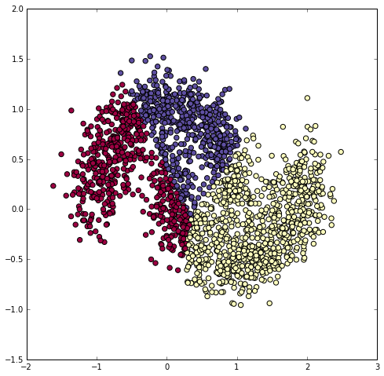

```python
# moon
np.random.seed(0)
X, y = datasets.make_moons(2000, noise=0.2)

centers = kmeans(X, k=3)
labels = [find_closest_centroid(p, centers) for p in X]

fig = plt.figure(1, figsize=(8, 8))
plt.clf()
plt.scatter(X[:,0], X[:,1], s=40, c=labels, cmap=plt.cm.Spectral)

ax.w_xaxis.set_ticklabels([])
ax.w_yaxis.set_ticklabels([])
ax.w_zaxis.set_ticklabels([])

plt.show()
```

```
0.0
clusters :3
```

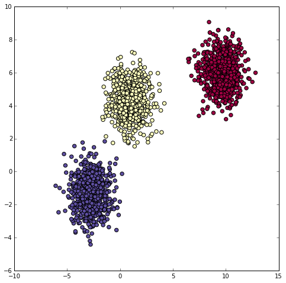

```python
# blob
np.random.seed(0)
X, y = datasets.make_blobs(n_samples=2000, centers=3, n_features=20, random_state=0)

centers = kmeans(X, k=3)
labels = [find_closest_centroid(p, centers) for p in X]

fig = plt.figure(1, figsize=(8, 8))
plt.clf()
plt.scatter(X[:,0], X[:,1], s=40, c=labels, cmap=plt.cm.Spectral)

ax.w_xaxis.set_ticklabels([])
ax.w_yaxis.set_ticklabels([])
ax.w_zaxis.set_ticklabels([])
ax.set_xlabel('Petal width')
ax.set_ylabel('Sepal length')
ax.set_zlabel('Petal length')

plt.show()
```

We can estimate that the algorithm works quite well since we have each time 3 distinct clusters that seem consistent, even with small MAX_ITERATIONS values.  
First, we applied the algorithm with 100 MAX_ITERATIONS. The clusters were well defined and the computation time was not that significant.  
When we try with 10 MAX_ITERATIONS, we observe that the execution is much more rapid, and provides basically the same results. Indeed, we can easily distinguish 3 differents clusters each time. (See the plots above).  
At last, with only 2 MAX_ITERATIONS, we observe that for the datasets 'iris' and 'blob', it is more or less the same results since the 3 differents parts are still well sorted. This may be due to the simplicity of the data, which may be not that difficult to cluster (for example, the 'blob' data seems to be already sortable in 3 clusters just looking at the plot before clustering...) On the other hand, with only 2 MAX_ITERATIONS for the dataset 'moon', the points are not well separated, and the clusters are very different with 2, 10, 100 iterations. In fact, the datapoints appear to be gathered in one big block, and there are many possibilities to split them.

That's enough about K-means for now. In the next section, we will apply MMLIB's K-means on Spark to deal with a large data in the real usecase.

# 2. Usecase: Network Intrusion

Some attacks attempt to flood a computer with network traffic. In some other cases, attacks attempt to exploit flaws in networking software in order to gain unauthorized access to a computer. Detecting an exploit in an incredibly large haystack of network requests is not easy.

Some exploit behaviors follow known patterns such as scanning every port in a short of time, sending a burst of request to a port... However, the biggest threat may be the one that has never been detected and classified yet. Part of detecting potential network intrusions is detecting anomalies. These are connections that aren't known to be attacks, but, do not resemble connections that have been observed in the past.

In this notebook, K-means is used to detect anomalous network connections based on statistics about each of them.

## 2.1. Data

The data comes from [KDD Cup 1999](http://kdd.ics.uci.edu/databases/kddcup99/kddcup99.html). The dataset is about 708MB and contains about 4.9M connections. For each connection, the data set contains information like the number of bytes sent, login attempts, TCP errors, and so on. Each connection is one line of CSV-formatted data, containing 38 features: back, buffer_overflow, ftp_write, guess_passwd, imap, ipsweep, land, loadmodule, multihop, neptune, nmap, normal, perl, phf, pod, portsweep, rootkit, satan, smurf, spy, teardrop, warezclient, warezmaster. For more details about each features, please follow this [link](http://kdd.ics.uci.edu/databases/kddcup99/kddcup99.html).

Many features take on the value 0 or 1, indicating the presence or absence of a behavior such as `su_attempted` in the 15th column. Some features are counts, like `num_file_creations` in the 17th columns. Some others are the number of sent and received bytes.

## 2.2. Clustering without using categorical features

First, we need to import some packages that are used in this notebook.

```python
import os
import sys
import re
from pyspark import SparkContext
from pyspark import SparkContext
from pyspark.sql import SQLContext
from pyspark.sql.types import *
from pyspark.sql import Row
from pyspark.sql.functions import *
%matplotlib inline
import matplotlib.pyplot as plt
import pandas as pd
import numpy as np
import pyspark.sql.functions as func
import matplotlib.patches as mpatches
from pyspark.mllib.clustering import KMeans, KMeansModel

input_path = "/datasets/k-means/kddcup.data"
raw_data = sc.textFile(input_path, 12)
```

### 2.2.1. Loading data

There are two types of features: numerical features and categorical features. Currently, to get familiar with the data and the problem, we only use numerical features. In our data, we also have pre-defined groups for each connection, which we can use later as our "ground truth" for verifying our results.

**Note 1**: we don't use the labels in the training phase !!!

**Note 2**: in general, since clustering is un-supervised, you don't have access to ground truth. For this reason, several metrics to judge the quality of clustering have been devised. For a short overview of such metrics, follow this [link](https://en.wikipedia.org/wiki/Cluster_analysis#Internal_evaluation). Note that computing such metrics, that is trying to assess the quality of your clustering results, is as computationally intensive as computing the clustering itself!

[figure not shown]

#### Question 2

Write function `parseLine` to construct a tuple of `(label, vector)` for each connection, extract the data that contains only the data points (without label), then print the number of connections.

Where,

- `label` is the pre-defined label of each connection
- `vector` is a numpy array that contains values of all features, but the label and the categorial features at index `1,2,3` of each connection. Each `vector` is a data point.

```python
def parseLine(line):
    cols = line.split(',')
    # label is the last column
    label = cols[-1]
    # vector is every column, except the label
    vector = cols[0:-1]

    # delete values of columns that have index 1->3 (categorical features)
    vector= [vector[0]] + vector[4:]

    # convert each value from string to float
    vector = [float(i) for i in vector]
    vector= np.array(vector)
    return (label, vector)


labelsAndData = raw_data.map(parseLine)

# we only need the data, not the label
data = labelsAndData.values().cache()
# data = labelsAndData.map(lambda elem: elem[1]).cache()

print(data.first())

# number of connections
n = data.count()
print('Number of connections: '+str(n))
```

```
[  0.00000000e+00   2.15000000e+02   4.50760000e+04   0.00000000e+00
   0.00000000e+00   0.00000000e+00   0.00000000e+00   0.00000000e+00
   1.00000000e+00   0.00000000e+00   0.00000000e+00   0.00000000e+00
   0.00000000e+00   0.00000000e+00   0.00000000e+00   0.00000000e+00
   0.00000000e+00   0.00000000e+00   0.00000000e+00   1.00000000e+00
   1.00000000e+00   0.00000000e+00   0.00000000e+00   0.00000000e+00
   0.00000000e+00   1.00000000e+00   0.00000000e+00   0.00000000e+00
   0.00000000e+00   0.00000000e+00   0.00000000e+00   0.00000000e+00
   0.00000000e+00   0.00000000e+00   0.00000000e+00   0.00000000e+00
   0.00000000e+00   0.00000000e+00]
Number of connections: 4898431
```

[figure not shown]

#### Question 3

Using K-means algorithm of MLLIB, cluster the connections into two groups then plot the result. Why two groups? In this case, we are just warming up, we're testing things around, so "two groups" has no particular meaning.

You can use the following parameters:

- `maxIterations=10`
- `runs=10`
- `initializationMode="random"`

Discuss the result from your figure.

```python
clusters = KMeans.train(data, 2, maxIterations=10, runs=10, initializationMode="random")
```

We chose randomly the features at indexes 1 and 2 to have a 2d-plot that is able to represent the data in an easy way. Thus, we decided to plot the index-1-feature on axis x and the index-2-feature on axis y.

```python
# cluster 0
data_x_0 = data.filter(lambda x: clusters.predict(x)==0).map(lambda x: x[1]).collect()
data_y_0 = data.filter(lambda x: clusters.predict(x)==0).map(lambda x: x[2]).collect()
```

```python
# cluster 1
data_x_1 = data.filter(lambda x: clusters.predict(x)==1).map(lambda x: x[1]).collect()
data_y_1 = data.filter(lambda x: clusters.predict(x)==1).map(lambda x: x[2]).collect()
```

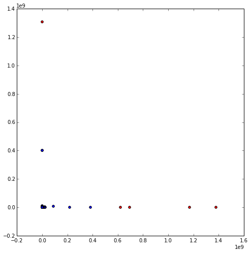

```python
# plot cluster 0 in red and cluster 1 in blue
fig = plt.figure(figsize=(8, 8))
ax = fig.add_subplot(111)
ax.scatter(data_x_0, data_y_0, c='r')
ax.scatter(data_x_1, data_y_1, c='b')
```

Plotting the data, we can notice that almost all the points are gathered around the graph origin (0,0), while the few other points have a different x or y. These points could be examples of unusual connections.  
Clustering the datapoints in 2 clusters highlights some of the 'lonely' datapoints. Then, improving the model could give more accurate results and highlight the dataset anomalies.

### 2.2.3. Evaluating model

[figure not shown]

#### Question 4

One of the simplest method to evaluate our result is calculate the Within Set Sum of Squared Errors (WSSSE), or simply, 'Sum of Squared Errors'. An error of a data point is defined as it's distance to the closest cluster center.

```python
from operator import add
```

```python
# Evaluate clustering by computing Within Set Sum of Squared Errors
def error(clusters, point):
    closest_center = clusters.centers[clusters.predict(point)]
    return euclidean_distance(closest_center, point)**2

WSSSE = data.map(lambda point: error(clusters, point)).reduce(add)
print("Within Set Sum of Squared Error = " + str(WSSSE))
```

```
Within Set Sum of Squared Error = 3.05254895755e+18
```

```python
# avec outil
clusters.computeCost(data)
```

```
3.052548957548266e+18
```

[figure not shown]

#### Question 5

This is a good opportunity to use the given labels to get an intuitive sense of what went into these two clusters, by counting the labels within each cluster. Complete the following code that uses the model to assign each data point to a cluster, and counts occurrences of cluster and label pairs. What do you think about the result ?

```python
# for each data, return ([cluster 0 or 1 which it belongs to], [label], [count = 1])
# then reduce by adding all the counts by occurence
clusterLabelCount = labelsAndData.map(lambda data: ((clusters.predict(data[1]), data[0]), 1)).reduceByKey(add).collect()

for item in clusterLabelCount:
    print(item)
```

```
((1, 'normal.'), 972781)
((1, 'rootkit.'), 10)
((1, 'warezmaster.'), 20)
((1, 'warezclient.'), 1020)
((1, 'phf.'), 4)
((1, 'perl.'), 3)
((1, 'land.'), 21)
((1, 'spy.'), 2)
((1, 'portsweep.'), 10408)
((1, 'ftp_write.'), 8)
((1, 'buffer_overflow.'), 30)
((1, 'satan.'), 15892)
((1, 'pod.'), 264)
((1, 'neptune.'), 1072017)
((1, 'teardrop.'), 979)
((1, 'nmap.'), 2316)
((1, 'smurf.'), 2807886)
((0, 'portsweep.'), 5)
((1, 'imap.'), 12)
((1, 'ipsweep.'), 12481)
((1, 'multihop.'), 7)
((1, 'back.'), 2203)
((1, 'guess_passwd.'), 53)
((1, 'loadmodule.'), 9)
```

We can see that the labels are not equally distributed: some labels are over-represented, like "smurf", "neptune" and "normal".  
The 5 single points belonging to the cluster 0 have the same label 'portsweep'. All the other points are in the cluster 1, including 10408 points also labeled 'portsweep'. It could be interesting to remove the data labeled "portsweep" in order to have new clusters, perhaps more relevant ones.

### 2.2.4. Choosing K

How many clusters are appropriate for a dataset? In particular, for our own dataset, it's clear that there are 23 distinct behavior patterns in the data, so it seems that k could be at least 23, or likely, even more. In other cases, we even don't have any information about the number of patterns at all (remember, generally your data is not labelled!). Our task now is finding a good value of $k$. For doing that, we have to build and evaluate models with different values of $k$. A clustering could be considered good if each data point were near to its closest centroid. One of the ways to evaluate a model is calculating the Mean of Squared Errors of all data points.

[figure not shown]

#### Question 6

Complete the function below to calculate the MSE of each model that is corresponding to each value of $k$. Plot the results. From the obtained result, what is the best value for $k$ ? Why ?

```python
def clusteringScore(data, k):
    clusters = KMeans.train(data, k, maxIterations=10, runs=10, initializationMode="random")
    # calculate mean square error
    WSSSE = data.map(lambda point: error(clusters, point)).reduce(add)
    total = data.count()
    return WSSSE/total
```

```
197237202017.0
197244860169.0
197208648273.0
197208208505.0
197204483983.0
197206215211.0
168291835820.0
197200434536.0
168296303040.0
168291501180.0
Computation time: 2293.6023099422455seconds
```

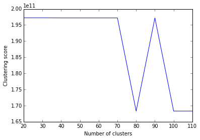

```python
import time

t1 = time.time()
# k: the number of clusters

scores = [clusteringScore(data, k) for k in range(20, 120, 10)]
for score in scores:
    print(score)

# plot results
plt.plot(range(20, 120, 10), scores)
plt.xlabel('Number of clusters')
plt.ylabel('Clustering score')

t2 = time.time()
time = t2 - t1
print('Computation time: '+str(time)+'seconds')
```

Plotting the clustering scores shows a few minima in the range we chose: k=80 is a local minima and so are k=100 and k=110 (which is in fact the best value for k in the given range).  
It would be interesting to plot more values of k to have more accurate results and see what is going on between local minima and maxima (between 80 and 100 for example). Unfortunately, the computation time is too significant to make large tests.

### 2.2.5 Normalizing features

K-means clustering treats equally all dimensions/directions of the space and therefore tends to produce more or less spherical (rather than elongated) clusters. In this situation, leaving variances uneven is equivalent to putting more weight on variables with smaller variance, so clusters will tend to be separated along variables with greater variance.

In our notebook, since Euclidean distance is used, the clusters will be influenced strongly by the magnitudes of the variables, especially by outliers. Normalizing will remove this bias.

Each feature can be normalized by converting it to a standard score. This means subtracting the mean of the feature’s values from each value, and dividing by the standard deviation

$normalize_i=\frac{feature_i - \mu_i}{\sigma_i}$

Where,

- $normalize_i$ is the normalized value of feature $i$
- $\mu_i$ is the mean of feature $i$
- $\sigma_i$ is the standard deviation of feature $i$

[figure not shown]

#### Question 7

Complete the code below to normalize the data. Print the first 5 lines of the new data.

HINT: If $\sigma_i = 0$ then $normalize_i=feature_i - \mu_i$

```python
def normalizeData(data):
    # number of connections
    n = data.count()

    # calculate the sum of each feature
    sums = data.reduce(add)
    print(sums)

    # calculate means
    means = sums/n

    # calculate the sum square of each feature
    sumSquares = data.map(lambda x: x**2).reduce(add)
    print(sumSquares)

    # calculate standard deviation of each feature
    stdevs = np.sqrt(sumSquares/n - means**2)
    stdevs[stdevs == 0] = 1

    def normalize(point):
        return (point - means)/stdevs

    return data.map(normalize)
```

```python
normalizedData = normalizeData(data).cache()
normalizedData.take(5)
```

```
[  2.36802060e+08   8.98676524e+09   5.35703589e+09   2.80000000e+01
   3.17800000e+03   3.90000000e+01   6.09250000e+04   1.57000000e+02
   7.03067000e+05   3.96200000e+04   3.34000000e+02   1.80000000e+02
   6.33610000e+04   5.82300000e+03   3.64000000e+02   5.00200000e+03
   0.00000000e+00   2.00000000e+00   4.09100000e+03   1.64084428e+09
   1.44634545e+09   8.71775140e+05   8.72101730e+05   2.82468470e+05
   2.82786920e+05   3.86919313e+06   1.03746840e+05   1.38433600e+05
   1.14124176e+09   9.26852923e+08   3.69201228e+06   1.50436230e+05
   2.96380553e+06   3.16639800e+04   8.72367200e+05   8.71361620e+05
   2.83755350e+05   2.82440660e+05]
[  2.57433563e+12   4.34145810e+18   2.03795314e+18   2.80000000e+01
   8.99800000e+03   2.55000000e+02   1.07812100e+06   2.61000000e+02
   7.03067000e+05   7.28519560e+07   3.34000000e+02   3.20000000e+02
   7.59678130e+07   7.55510000e+04   3.74000000e+02   6.18200000e+03
   0.00000000e+00   2.00000000e+00   4.09100000e+03   7.69775149e+11
   7.23474027e+11   8.69483055e+05   8.71016042e+05   2.80516842e+05
   2.81481562e+05   3.79857761e+06   3.57109172e+04   1.00690484e+05
   2.85964840e+11   2.30321984e+11   3.61091538e+06   6.23315491e+04
   2.92650429e+06   8.54361660e+03   8.69554008e+05   8.70465611e+05
   2.77693059e+05   2.77620044e+05]
```

```
[array([ -6.68331854e-02,  -1.72038228e-03,   6.81884351e-02,
         -2.39084686e-03,  -1.51391734e-02,  -1.10348462e-03,
         -2.65207600e-02,  -4.39091558e-03,   2.44279187e+00,
         -2.09732783e-03,  -8.25770840e-03,  -4.54646139e-03,
         -3.28458917e-03,  -9.57233922e-03,  -8.50457842e-03,
         -2.87561127e-02,   0.00000000e+00,  -6.38979005e-04,
         -2.89113034e-02,  -1.57541507e+00,  -1.19624324e+00,
         -4.66042614e-01,  -4.65755574e-01,  -2.48285775e-01,
         -2.48130352e-01,   5.39733093e-01,  -2.56056520e-01,
         -2.01059296e-01,  -3.63913926e+00,  -1.78651044e+00,
         -1.83302273e+00,  -2.82939000e-01,  -1.25793664e+00,
         -1.56668488e-01,  -4.66404784e-01,  -4.65453641e-01,
         -2.50831829e-01,  -2.49631966e-01]),
 array([ -6.68331854e-02,  -1.77667956e-03,   5.32451452e-03,
         -2.39084686e-03,  -1.51391734e-02,  -1.10348462e-03,
         -2.65207600e-02,  -4.39091558e-03,   2.44279187e+00,
         -2.09732783e-03,  -8.25770840e-03,  -4.54646139e-03,
         -3.28458917e-03,  -9.57233922e-03,  -8.50457842e-03,
         -2.87561127e-02,   0.00000000e+00,  -6.38979005e-04,
         -2.89113034e-02,  -1.57069789e+00,  -1.19217808e+00,
         -4.66042614e-01,  -4.65755574e-01,  -2.48285775e-01,
         -2.48130352e-01,   5.39733093e-01,  -2.56056520e-01,
         -2.01059296e-01,  -3.62351937e+00,  -1.77706870e+00,
          5.98966843e-01,  -2.82939000e-01,   8.21118739e-01,
         -1.56668488e-01,  -4.66404784e-01,  -4.65453641e-01,
         -2.50831829e-01,  -2.49631966e-01]),
 array([ -6.68331854e-02,  -1.69807581e-03,   2.08332760e-04,
         -2.39084686e-03,  -1.51391734e-02,  -1.10348462e-03,
         -2.65207600e-02,  -4.39091558e-03,   2.44279187e+00,
         -2.09732783e-03,  -8.25770840e-03,  -4.54646139e-03,
         -3.28458917e-03,  -9.57233922e-03,  -8.50457842e-03,
         -2.87561127e-02,   0.00000000e+00,  -6.38979005e-04,
         -2.89113034e-02,  -1.57541507e+00,  -1.19624324e+00,
         -4.66042614e-01,  -4.65755574e-01,  -2.48285775e-01,
         -2.48130352e-01,   5.39733093e-01,  -2.56056520e-01,
         -2.01059296e-01,  -3.60789948e+00,  -1.76762697e+00,
          5.98966843e-01,  -2.82939000e-01,  -2.18408950e-01,
         -1.56668488e-01,  -4.66404784e-01,  -4.65453641e-01,
         -2.50831829e-01,  -2.49631966e-01]),
 array([ -6.68331854e-02,  -1.70126245e-03,   1.45482068e-03,
```

[output cut: 10 more lines]

```
         -1.56668488e-01,  -4.66404784e-01,  -4.65453641e-01,
         -2.50831829e-01,  -2.49631966e-01]),
 array([ -6.68331854e-02,  -1.69488918e-03,  -9.42032957e-04,
         -2.39084686e-03,  -1.51391734e-02,  -1.10348462e-03,
         -2.65207600e-02,  -4.39091558e-03,   2.44279187e+00,
         -2.09732783e-03,  -8.25770840e-03,  -4.54646139e-03,
         -3.28458917e-03,  -9.57233922e-03,  -8.50457842e-03,
         -2.87561127e-02,   0.00000000e+00,  -6.38979005e-04,
         -2.89113034e-02,  -1.56598070e+00,  -1.18811292e+00,
         -4.66042614e-01,  -4.65755574e-01,  -2.48285775e-01,
         -2.48130352e-01,   5.39733093e-01,  -2.56056520e-01,
         -2.01059296e-01,  -3.57665969e+00,  -1.74874350e+00,
          5.98966843e-01,  -2.82939000e-01,  -7.38172794e-01,
         -1.56668488e-01,  -4.66404784e-01,  -4.65453641e-01,
         -2.50831829e-01,  -2.49631966e-01])]
```

[figure not shown]

#### Question 8

Using the new data, build different models with different values of $k \in [60,70,80,90,100,110]$. Evaluate the results by plotting them and choose the best value of $k$.

```
12.4009854102
11.7895646633
11.1999699069
11.3921662918
11.40273509
11.1912715866
Computation time: 1864.9927117824554seconds
```

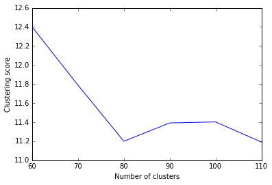

```python
import time

t1 = time.time()
scores = [clusteringScore(normalizedData, k) for k in range(60, 120, 10)]
for score in scores:
    print(score)

# plot results
plt.plot(range(60, 120, 10), scores)
plt.xlabel('Number of clusters')
plt.ylabel('Clustering score')

t2 = time.time()
time = t2 - t1
print('Computation time: '+str(time)+'seconds')
```

With the normalized data, the results look like the previous ones since the plot has basically the same shape (even if the values are way lower): k=80 and k=110 are still local minima and these values could be the best number of clusters for our model.

[figure not shown]

#### Question 9

Plot the clustering result to see the difference between before and after normalizing features. Discuss about the difference and explain why and if normalization was useful.

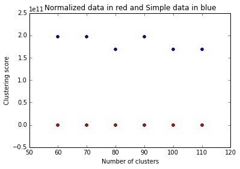

```python
norm_scores_list = [12.4009854102, 11.7895646633, 11.1999699069, 11.3921662918, 11.40273509, 11.1912715866]
norm_k_list = range(60, 120, 10)
norm_k_list_bis = range(62, 122, 10)
scores_list = [197237202017.0, 197244860169.0, 197208648273.0,\
          197208208505.0, 197204483983.0, 197206215211.0, \
          168291835820.0, 197200434536.0, 168296303040.0, 168291501180.0]

plt.scatter(norm_k_list, scores_list[4:])
plt.scatter(norm_k_list, norm_scores_list, c='r')
plt.xlabel('Number of clusters')
plt.ylabel('Clustering score')
plt.title('Normalized data in red and Simple data in blue')
plt.show()
```

On this graph showing the two models - in red the Normalized data, and in blue the simple data - we can see that the clustering score is almost null regarding to the other, but the shape of the two plots are quite similar. Then, the second model, with the normalized data, seems to be better than the other one since it is more adapted to every type of features values (like binary ones) and gives more precise results.  
The normalization was useful especially for the binary values: indeed, the normalization highlights the differences between different datapoints in a more accurate way and is more willing to spot unusual datapoints (which values are far from the average of the others).

## 2.3. Clustering using categorical features

### 2.3.1 Loading data

In the previous section, we ignored the categorical features of our data: this is not a good idea, since these categorical features can be important in providing useful information for clustering. The problem is that K-means (or at least, the one we have developed and the one we use from MLLib) only work with data points in a metric space. Informally, this means that operations such as addition, substraction and computing the mean of data points are trivial and well defined. For a more formal definition of what a metric space is, follow this [link](https://en.wikipedia.org/wiki/Metric_space#Definition).

What we will do next is to transform each categorical features into one or more numerical features. This approach is very widespread: imagine for example you wanted to use K-means to cluster text data. Then, the idea is to transform text data in $d$-dimensional vectors, and a nice way to do it is to use word2vec. If you're interested, follow this link to a nice [blog post](http://bigdatasciencebootcamp.com/posts/Part_3/clustering_news.html) on the problem.

There are two approaches:

- **Approach 1**: mapping **one** categorial feature to **one** numerical feature. The values in each categorical feature are encoded into unique numbers of the new numerical feature. For example, ['VERY HOT','HOT', 'COOL', 'COLD', 'VERY COLD'] will be encoded into [0,1,2,3,4,5]. However, by using this method, we implicit assume that the value of 'VERY HOT' is smaller than 'HOT'... This is not generally true.
- **Approach 2**: mapping mapping **one** categorial feature to **multiple** numerical features. Basically, a single variable with $n$ observations and $d$ distinct values, to $d$ binary variables with $n$ observations each. Each observation indicating the presence (1) or absence (0) of the $d^{th}$ binary variable. For example, ['house', 'car', 'tooth', 'car'] becomes

  ```
  [
  [1,0,0,0],
  [0,1,0,0],
  [0,0,1,0],
  [0,0,0,1],
  ]
  ```

We call the second approach "one-hot encoding". By using this approach, we keep the same role for all values of categorical features.

[figure not shown]

#### Question 10

Calculate the number of distinct categorical features value (at index `1,2,3`). Then construct a new input data using one-hot encoding for these categorical features (don't throw away numerical features!).

```python
# select column at index i
def feature(line, i):
    cols = line.split(',')
    feature = cols[i]
    return feature

# return a list with all the distinct values of feature at index i
dist_val_1 = raw_data.map(lambda line: feature(line, 1)).distinct().collect()
dist_val_2 = raw_data.map(lambda line: feature(line, 2)).distinct().collect()
dist_val_3 = raw_data.map(lambda line: feature(line, 3)).distinct().collect()

# define the number of distinct values for Features Of Columns 1, 2 and 3
len_foc1 = len(dist_val_1)
len_foc2 = len(dist_val_2)
len_foc3 = len(dist_val_3)

print(len_foc1)
print(len_foc2)
print(len_foc3)
```

```
3
70
11
```

Thus, the first categorical feature value will be a 3-digits-binary, the second will be a 70-digits-binary and the third, an 11-digits binary.

```python
def parseLineWithHotEncoding(line):
    cols = line.split(',')
    # label is the last column
    label = cols[-1]

    # vector is every column, except the label
    vector = cols[0:-1]

    # the binary features that are encoded from the first categorial feature
        # list of len_foc1 zeros
    featureOfCol1 = [0]*len_foc1
        # replace the 0 by a 1 at the same position as the value's in the list of distinct values
    featureOfCol1[dist_val_1.index(vector[1])] = 1

    # the binary features that are encoded from the second categorial feature
    featureOfCol2 = [0]*len_foc2
    featureOfCol2[dist_val_2.index(vector[2])] = 1

    # the binary features that are encoded from the third categorial feature
    featureOfCol3 = [0]*len_foc3
    featureOfCol3[dist_val_3.index(vector[3])] = 1

    # construct the new vector
    vector = ([vector[0]] + featureOfCol1 + featureOfCol2 + featureOfCol3 + vector[4:])

    # convert each value from string to float
    vector = np.array([float(i) for i in vector])

    return (label, vector)

labelsAndData = raw_data.map(parseLineWithHotEncoding)

# we only need the data, not the label
data = labelsAndData.values().cache()
normalizedData = normalizeData(data).cache()
```

[output not shown]

```python
data.first()
```

```
array([  0.00000000e+00,   0.00000000e+00,   0.00000000e+00,
         1.00000000e+00,   0.00000000e+00,   0.00000000e+00,
         0.00000000e+00,   0.00000000e+00,   0.00000000e+00,
         0.00000000e+00,   0.00000000e+00,   0.00000000e+00,
         0.00000000e+00,   0.00000000e+00,   0.00000000e+00,
         0.00000000e+00,   0.00000000e+00,   0.00000000e+00,
         0.00000000e+00,   0.00000000e+00,   1.00000000e+00,
         0.00000000e+00,   0.00000000e+00,   0.00000000e+00,
         0.00000000e+00,   0.00000000e+00,   0.00000000e+00,
         0.00000000e+00,   0.00000000e+00,   0.00000000e+00,
         0.00000000e+00,   0.00000000e+00,   0.00000000e+00,
         0.00000000e+00,   0.00000000e+00,   0.00000000e+00,
         0.00000000e+00,   0.00000000e+00,   0.00000000e+00,
         0.00000000e+00,   0.00000000e+00,   0.00000000e+00,
         0.00000000e+00,   0.00000000e+00,   0.00000000e+00,
         0.00000000e+00,   0.00000000e+00,   0.00000000e+00,
         0.00000000e+00,   0.00000000e+00,   0.00000000e+00,
         0.00000000e+00,   0.00000000e+00,   0.00000000e+00,
         0.00000000e+00,   0.00000000e+00,   0.00000000e+00,
         0.00000000e+00,   0.00000000e+00,   0.00000000e+00,
         0.00000000e+00,   0.00000000e+00,   0.00000000e+00,
         0.00000000e+00,   0.00000000e+00,   0.00000000e+00,
         0.00000000e+00,   0.00000000e+00,   0.00000000e+00,
         0.00000000e+00,   0.00000000e+00,   0.00000000e+00,
         0.00000000e+00,   0.00000000e+00,   0.00000000e+00,
         0.00000000e+00,   0.00000000e+00,   0.00000000e+00,
         1.00000000e+00,   0.00000000e+00,   0.00000000e+00,
         0.00000000e+00,   0.00000000e+00,   0.00000000e+00,
         0.00000000e+00,   2.15000000e+02,   4.50760000e+04,
         0.00000000e+00,   0.00000000e+00,   0.00000000e+00,
         0.00000000e+00,   0.00000000e+00,   1.00000000e+00,
         0.00000000e+00,   0.00000000e+00,   0.00000000e+00,
         0.00000000e+00,   0.00000000e+00,   0.00000000e+00,
         0.00000000e+00,   0.00000000e+00,   0.00000000e+00,
         0.00000000e+00,   1.00000000e+00,   1.00000000e+00,
         0.00000000e+00,   0.00000000e+00,   0.00000000e+00,
         0.00000000e+00,   1.00000000e+00,   0.00000000e+00,
         0.00000000e+00,   0.00000000e+00,   0.00000000e+00,
         0.00000000e+00,   0.00000000e+00,   0.00000000e+00,
         0.00000000e+00,   0.00000000e+00,   0.00000000e+00,
         0.00000000e+00,   0.00000000e+00])
```

```python
normalizedData.first()
```

```
array([ -6.68331854e-02,  -1.17143182e+00,  -2.03227620e-01,
         1.27225957e+00,  -1.46075028e-02,  -1.47812387e-02,
        -5.49678716e-03,  -9.15301835e-02,  -1.46702845e-02,
        -1.47674150e-02,  -1.46424147e-02,  -1.46214776e-02,
        -1.03136755e-02,  -1.46841996e-02,  -1.45584855e-02,
        -1.47050475e-02,  -1.45795131e-02,  -1.48019501e-02,
        -1.50753856e-02,  -1.46075028e-02,   2.61944684e+00,
        -1.46563562e-02,  -7.82586340e-04,  -2.01141450e-02,
        -1.48364049e-02,  -2.62850181e-02,  -1.01031483e-03,
        -1.48019501e-02,  -3.75334357e-02,  -1.47050475e-02,
        -1.47604982e-02,  -1.46563562e-02,  -1.45865155e-02,
        -1.46493871e-02,  -1.79569501e-02,  -4.51826342e-04,
        -1.47119903e-02,  -1.46841996e-02,  -3.31528172e-02,
        -1.46911522e-02,  -1.35548013e-03,  -1.46841996e-02,
        -1.48157416e-02,  -1.47743284e-02,  -1.41801106e-01,
        -1.44387514e-02,  -1.48295203e-02,  -1.48226325e-02,
        -1.16076420e+00,  -1.22699589e-01,  -1.46563562e-02,
        -1.45795131e-02,  -5.24981950e-03,  -1.46772437e-02,
        -3.26428655e-02,  -1.46424147e-02,  -6.38979005e-04,
        -1.09255797e-01,  -1.47743284e-02,  -1.46493871e-02,
        -5.38400824e-01,  -1.46633220e-02,  -2.95617956e-02,
        -5.78490754e-02,  -1.46841996e-02,  -1.56517412e-03,
        -1.46772437e-02,  -6.38979005e-04,  -1.46075028e-02,
        -2.79840711e-02,  -1.46005104e-02,  -1.47050475e-02,
        -1.45725073e-02,  -6.38979005e-04,  -3.41123357e-03,
        -1.04219960e-02,  -4.99064670e-03,  -1.45725073e-02,
         5.55181955e-01,  -4.64664784e-01,  -3.19491068e-03,
        -4.06829284e-02,  -3.30477393e-02,  -5.73312720e-03,
        -2.40993143e-01,  -1.72038228e-03,   6.81884351e-02,
        -2.39084686e-03,  -1.51391734e-02,  -1.10348462e-03,
        -2.65207600e-02,  -4.39091558e-03,   2.44279187e+00,
        -2.09732783e-03,  -8.25770840e-03,  -4.54646139e-03,
        -3.28458917e-03,  -9.57233922e-03,  -8.50457842e-03,
        -2.87561127e-02,   0.00000000e+00,  -6.38979005e-04,
        -2.89113034e-02,  -1.57541507e+00,  -1.19624324e+00,
        -4.66042614e-01,  -4.65755574e-01,  -2.48285775e-01,
        -2.48130352e-01,   5.39733093e-01,  -2.56056520e-01,
        -2.01059296e-01,  -3.63913926e+00,  -1.78651044e+00,
        -1.83302273e+00,  -2.82939000e-01,  -1.25793664e+00,
        -1.56668488e-01,  -4.66404784e-01,  -4.65453641e-01,
        -2.50831829e-01,  -2.49631966e-01])
```

### 2.3.2. Building models

[figure not shown]

#### Question 11

Using the new data, cluster the connections with different values of $k \in [80,90,100,110,120,130,140,150,160]$. Evaluate the results and choose the best value of $k$ as previous questions.

```
63.8413258674
63.4331971355
61.022230797
56.196841512
57.0052477341
56.5726929903
51.0255518358
50.1671718409
Computation time: 4659.722819328308seconds
```

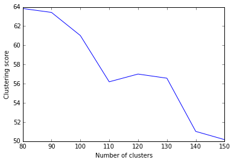

```python
import time

t1 = time.time()

scores = [clusteringScore(normalizedData, k) for k in range(80, 160, 10)]
for score in scores:
    print(score)

# plot results
plt.plot(range(80, 160, 10), scores)
plt.xlabel('Number of clusters')
plt.ylabel('Clustering score')

t2 = time.time()
time = t2 - t1
print('Computation time: '+str(time)+'seconds')
```

Now we have taken into account the three categorical features 1, 2 and 3, we can see different results than previously: k=80 is not a minima anymore as the clustering scores seem to decrease while the number of clusters increases. Then, k=150 is a local minima and seems to be the best value of k for our model.  
These differences highlight the fact that the categorical features 1, 2 and 3 have quite a strong impact on the clustering task and needed to be added to the study.

## 2.4. Anomaly detection

When we have a new connection data (e.g., one that we never saw before), we simply find the closest cluster for it, and use this information as a proxy to indicate whether the data point is anomalous or not. A simple approach to decide wheter there is an anomaly or not, amounts to measuring the new data point’s distance to its nearest centroid. If this distance exceeds some thresholds, it is anomalous.

[figure not shown]

#### Question 12

Build your model with the best value of $k$ in your opinion. Then, detect the anomalous connections in our data. Plot and discuss your result.

HINT: The threshold has strong impact on the result. Be careful when choosing it! A simple way to choose the threshold's value is picking up a distance of a data point from among known data. For example, the 100th-farthest data point distance can be an option.

The best thing to plot would be the distances between every point and its nearest centroid. Then, after computing the model with our best value of k, we calculate these distances and represent them on a scatter-plot.

```python
k_best_value = 150

# compute the model with the best value of k
clusters_12 = KMeans.train(normalizedData, k_best_value, maxIterations=10, runs=10, initializationMode="random")
```

We could plot the datapoints sorted in the different clusters to have a first approximation and see if anomalous connections can already be detected, but the computation time might be too significant.  
Thus, we need to compute the distances between each point and its nearest centroid.  
For computational time issues, we decided to work on a reduced dataset, with 100000 samples from the normalized dataset.

[figure not shown]

```python
reduced_data = normalizedData.takeSample(False, 100000, 5)

y = []

for point in reduced_data:
    closest_center_test = clusters_12.centers[clusters_12.predict(point)]
    y.append(euclidean_distance(closest_center_test, point))

plt.plot(range(len(reduced_data)), the_100th)
plt.scatter(range(len(reduced_data)), y)
plt.show()
```

[output not shown]

What we see is consistent: a large part of the data is close to zero, which means that they are quite close to their cluster center. But as we expected, some points are farther from their corresponding center: these points could represent unusual connections since they are not similar to the others (high distance from their cluster).

```python
distances = normalizedData.map(lambda point: euclidean_distance(clusters_12.centers[clusters_12.predict(point)], point))
```

```python
far_100 = distances.takeOrdered(100, key= lambda x: -x)
```

```python
the_100th = far_100[99]
print('The 100th-farthest data point distance: '+str(the_100th))
```

```
The 100th-farthest data point distance: 387.850445374
```

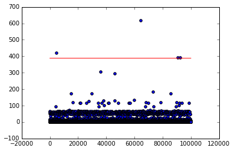

```python
reduced_data = normalizedData.takeSample(False, 100000, 5)

y = []
y1 = []

for point in reduced_data:
    closest_center_test = clusters_12.centers[clusters_12.predict(point)]
    y.append(euclidean_distance(closest_center_test, point))

for i in range(len(reduced_data)):
    y1.append(the_100th)

plt.plot(range(len(reduced_data)), y1, 'r')
plt.scatter(range(len(reduced_data)), y)
plt.show()
```

[figure not shown]

#### Question 13

Try other methods to find the best value for $k$ such as `silhouette`, `entropy`... In particular, with this data, you can take advantage of predefined labels to calculate the quality of model using entropy... However, we suggest you to try with `silhouette`. It's more general and can work with any dataset (with and without predefined labels).

Here are some additional information about the metrics we suggest to use:

Note: you are free to play with any relevant evaluation metric you think appropriate for your work!

This code (found on internet) should compute the silhouette method to determine the best value for k.  
Unfortunately, even if we considered the reduced dataset as above, the computational time was too significant for us to finish...

```python
from __future__ import print_function
from sklearn.cluster import KMeans
from sklearn.metrics import silhouette_samples, silhouette_score

import matplotlib.cm as cm

# Generating the sample data from make_blobs
# This particular setting has one distict cluster and 3 clusters placed close
# together.
# X, y = make_blobs(n_samples=500,
#                   n_features=2,
#                   centers=4,
#                   cluster_std=1,
#                   center_box=(-10.0, 10.0),
#                   shuffle=True,
#                   random_state=1)  # For reproducibility

reduced_data = normalizedData.takeSample(False, 100000, 5)
X = np.array(reduced_data)

range_n_clusters = [2, 3, 4, 5, 6]

for n_clusters in range_n_clusters:
    # Create a subplot with 1 row and 2 columns
    fig, (ax1, ax2) = plt.subplots(1, 2)
    fig.set_size_inches(18, 7)

    # The 1st subplot is the silhouette plot
    # The silhouette coefficient can range from -1, 1 but in this example all
    # lie within [-0.1, 1]
    ax1.set_xlim([-0.1, 1])
    # The (n_clusters+1)*10 is for inserting blank space between silhouette
    # plots of individual clusters, to demarcate them clearly.
    ax1.set_ylim([0, len(X) + (n_clusters + 1) * 10])

    # Initialize the clusterer with n_clusters value and a random generator
    # seed of 10 for reproducibility.
    clusterer = KMeans(n_clusters=n_clusters, random_state=10)
    cluster_labels = clusterer.fit_predict(X)

    # The silhouette_score gives the average value for all the samples.
    # This gives a perspective into the density and separation of the formed
    # clusters
    silhouette_avg = silhouette_score(X, cluster_labels)
    print("For n_clusters =", n_clusters,
          "The average silhouette_score is :", silhouette_avg)

    # Compute the silhouette scores for each sample
    sample_silhouette_values = silhouette_samples(X, cluster_labels)

    y_lower = 10
    for i in range(n_clusters):
        # Aggregate the silhouette scores for samples belonging to
        # cluster i, and sort them
        ith_cluster_silhouette_values = \
            sample_silhouette_values[cluster_labels == i]

        ith_cluster_silhouette_values.sort()

        size_cluster_i = ith_cluster_silhouette_values.shape[0]
        y_upper = y_lower + size_cluster_i

        color = cm.spectral(float(i) / n_clusters)
        ax1.fill_betweenx(np.arange(y_lower, y_upper),
                          0, ith_cluster_silhouette_values,
                          facecolor=color, edgecolor=color, alpha=0.7)

        # Label the silhouette plots with their cluster numbers at the middle
        ax1.text(-0.05, y_lower + 0.5 * size_cluster_i, str(i))

        # Compute the new y_lower for next plot
        y_lower = y_upper + 10  # 10 for the 0 samples

    ax1.set_title("The silhouette plot for the various clusters.")
    ax1.set_xlabel("The silhouette coefficient values")
    ax1.set_ylabel("Cluster label")

    # The vertical line for average silhoutte score of all the values
    ax1.axvline(x=silhouette_avg, color="red", linestyle="--")

    ax1.set_yticks([])  # Clear the yaxis labels / ticks
    ax1.set_xticks([-0.1, 0, 0.2, 0.4, 0.6, 0.8, 1])

    # 2nd Plot showing the actual clusters formed
    colors = cm.spectral(cluster_labels.astype(float) / n_clusters)
    ax2.scatter(X[:, 0], X[:, 1], marker='.', s=30, lw=0, alpha=0.7,
                c=colors)

    # Labeling the clusters
    centers = clusterer.cluster_centers_
    # Draw white circles at cluster centers
    ax2.scatter(centers[:, 0], centers[:, 1],
                marker='o', c="white", alpha=1, s=200)

    for i, c in enumerate(centers):
        ax2.scatter(c[0], c[1], marker='$%d$' % i, alpha=1, s=50)

    ax2.set_title("The visualization of the clustered data.")
    ax2.set_xlabel("Feature space for the 1st feature")
    ax2.set_ylabel("Feature space for the 2nd feature")

    plt.suptitle(("Silhouette analysis for KMeans clustering on sample data "
                  "with n_clusters = %d" % n_clusters),
                 fontsize=14, fontweight='bold')

    plt.show()
```

[figure not shown]

#### Question 14

Implement K-means on Spark so that It can work with large datasets in parallel. Test your algorithm with our dataset in this notebook. Compare our algorithm with the algorithm from MLLIB.

Let's clarify the meaning of this question: what we want is for students to design the K-means algorithm for the parallel programming model exposed by Spark. You are strongly invited to use the Python API (pyspark). So, at the end of the day, you will operate on RDDs, and implement a "map/reduce" algorithm that performs the two phases of the standard K-means algorithm, i.e. the assignment step and the update step.